# Empirical Project 2

```r
#looks like we could possibly have a fuzzy regression discontinuity
```

Similarly for part b, let’s keep our nice graphs and recreate them binned.

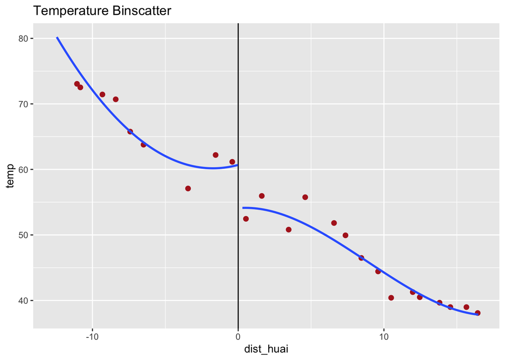

```r
#duplicate for the other variables
temp_binscatter <- river %>% group_by(dist_bins) %>%
      summarise(dist_huai = mean(dist_huai), temp = mean(temp)) %>%
      ggplot(aes(x = dist_huai, y = temp)) +
      geom_point(colour = "firebrick", size = 2, alpha = 1) +
      ggtitle("Temperature Binscatter") + geom_vline(xintercept = 0) +
      geom_smooth(data = river %>% filter(north_huai_f == 1), se = FALSE,
                  method = "lm", formula = y ~ poly(x, 3)) +
      geom_smooth(data = river %>% filter(north_huai_f == 0), se = FALSE,
                  method = "lm", formula = y ~ poly(x, 2))

prcp_binscatter <- river %>% group_by(dist_bins) %>%
      summarise(dist_huai = mean(dist_huai), prcp = mean(prcp)) %>%
      ggplot(aes(x = dist_huai, y = prcp)) +
      geom_point(colour = "firebrick", size = 2, alpha = 1) +
      ggtitle("Precipitation Binscatter") + geom_vline(xintercept = 0) +
      geom_smooth(data = river %>% filter(north_huai_f == 1), se = FALSE,
                  method = "lm", formula = y ~ poly(x, 3)) +
      geom_smooth(data = river %>% filter(north_huai_f == 0), se = FALSE,
                  method = "lm", formula = y ~ poly(x, 3))

wspd_binscatter <- river %>% group_by(dist_bins) %>%
        summarise(dist_huai = mean(dist_huai), wspd = mean(wspd)) %>%
        ggplot(aes(x = dist_huai, y = wspd)) +
        geom_point(colour = "firebrick", size = 2, alpha = 1) +
        ggtitle("Wind Speed Binscatter") + geom_vline(xintercept = 0) +
        geom_smooth(data = river %>% filter(north_huai_f == 1), se = FALSE,
                    method = "lm", formula = y ~ poly(x, 4)) +
        geom_smooth(data = river %>% filter(north_huai_f == 0), se = FALSE,
                    method = "lm", formula = y ~ poly(x, 3))

temp_binscatter
```

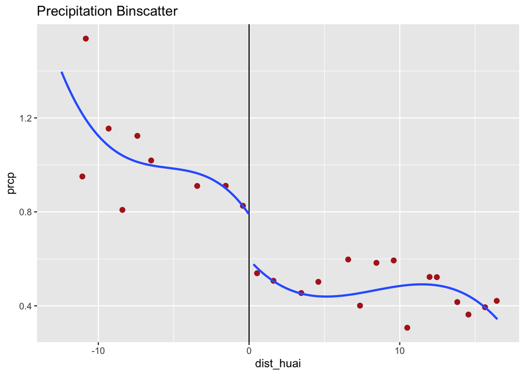

```r
prcp_binscatter
```

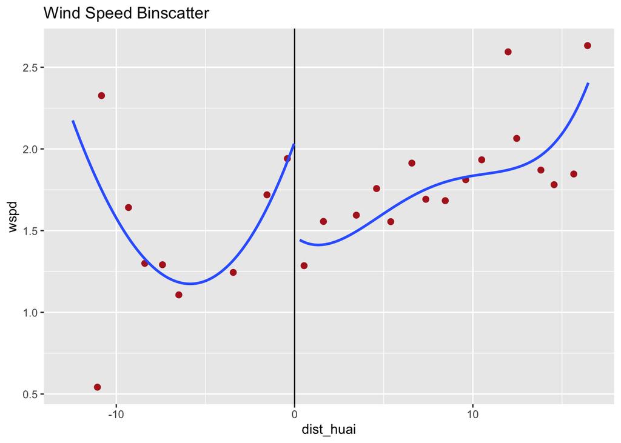

```r
wspd_binscatter
```

**5. Regression analysis. Run the regressions that correspond to your three graphs in 4a and 4b to quantify the discontinuities that you see in the data. Report a 95% confidence interval for each of these estimates. (more written about this in the assignment)**

The Regression in Regression Discontinuity:

Our goal is to estimate the diff in outcomes for just-treated vs. just-untreated. $𝜏^𝑅𝜏^𝐷 =𝐸[𝑌_𝑖(1)−𝑌_𝑖(0)|𝑋_𝑖=𝑐]=lim𝑥↓𝑐[𝐸[𝑌𝑖(1)𝑋_𝑖=𝑥]]−lim𝑥↑𝑐[𝐸[𝑌_𝑖(0)|𝑋_𝑖=𝑥]]$

We implement this by comparing average outcomes just below and above the cutoff

Where $−ℎ≤𝑋𝑖≤𝑐+ℎ$ is the bandwidth which we’re “close” to c. the variable name is h.

This leads to the regression-based RD:

$Y_𝑖=𝛼+𝜏𝐷𝑖_+𝜀_𝑖$ for $𝑐−ℎ≤𝑋𝑖≤𝑐+ℎ$ where $𝐷_𝑖=1(𝑋_𝑖≥𝑐)$

This means were only looking at observations that are very close to our cutoff of c = 0.

```r
#load new package needed for RD regressions, although it is outdated.

#this gives the high and low bandwidth levels
rdbwselect_2014(y = huai_data$pm10, x = huai_data$dist_huai, bwselect = "IK")
```

```
## Call:
## rdbwselect_2014(y = huai_data$pm10, x = huai_data$dist_huai,
##     bwselect = "IK")
##
## BW Selector   IK
## Number of Obs 154
## NN Matches    3
## Kernel Type   Triangular
##
##                    Left Right
## Number of Obs      80   74
## Order Loc Poly (p) 1    1
## Order Bias (q)     2    2
##
##             h        b
## [1,] 9.296907 6.963921
```

```r
#a regression on
lm(huai_data$pm10~huai_data$dist_huai, data = huai_data) %>% tidy(conf.int = TRUE)
```

| term | estimate | std.error | statistic | p.value | conf.low | conf.high |
| --- | --- | --- | --- | --- | --- | --- |
| (Intercept) | 102 | 2.64 | 38.6 | 1.94e-80 | 96.6 | 107 |
| huai_data$dist_huai | 2.32 | 0.4 | 5.82 | 3.42e-08 | 1.53 | 3.11 |

```r
#regressions
options(width = 90,
        xtable.comment = FALSE, xtable.caption.placement = "top")

#Need to install a new package for this and what I want
library(xtable)
#pm10 regression
pm10_reg <- lm(pm10~dist_huai + north_huai + dist_huai:north_huai, data=river_pm) %>% tidy(conf.int=TRUE)
pm10_reg
```

| term | estimate | std.error | statistic | p.value | conf.low | conf.high |
| --- | --- | --- | --- | --- | --- | --- |
| (Intercept) | 106 | 5.62 | 18.8 | 2.56e-41 | 94.6 | 117 |
| dist_huai | 4.36 | 0.996 | 4.38 | 2.22e-05 | 2.39 | 6.33 |
| north_huai | 32.1 | 8.12 | 3.96 | 0.000117 | 16.1 | 48.1 |
| dist_huai:north_huai | -6.89 | 1.27 | -5.45 | 2.04e-07 | -9.39 | -4.39 |

```r
#use x table to display
xtable(pm10_reg, caption="Regression of PM10 Levels on Distance from Huai River")
```

| term | estimate | std.error | statistic | p.value | conf.low | conf.high |
| --- | --- | --- | --- | --- | --- | --- |
| (Intercept) | 106 | 5.62 | 18.8 | 2.56e-41 | 94.6 | 117 |
| dist_huai | 4.36 | 0.996 | 4.38 | 2.22e-05 | 2.39 | 6.33 |
| north_huai | 32.1 | 8.12 | 3.96 | 0.000117 | 16.1 | 48.1 |
| dist_huai:north_huai | -6.89 | 1.27 | -5.45 | 2.04e-07 | -9.39 | -4.39 |

```r
#temperature regression
temp_reg <- lm(temp~dist_huai + north_huai + dist_huai:north_huai, data=river_pm) %>% tidy(conf.int=TRUE)
temp_reg
```

| term | estimate | std.error | statistic | p.value | conf.low | conf.high |
| --- | --- | --- | --- | --- | --- | --- |
| (Intercept) | 57.7 | 0.988 | 58.4 | 1.46e-104 | 55.7 | 59.6 |
| dist_huai | -1.23 | 0.18 | -6.85 | 1.78e-10 | -1.59 | -0.876 |
| north_huai | -1.29 | 1.41 | -0.912 | 0.363 | -4.08 | 1.5 |
| dist_huai:north_huai | 0.0622 | 0.224 | 0.278 | 0.782 | -0.38 | 0.505 |

```r
#use x table to display
xtable(temp_reg, caption="Regression of Temperature on Distance from Huai River")
```

| term | estimate | std.error | statistic | p.value | conf.low | conf.high |
| --- | --- | --- | --- | --- | --- | --- |
| (Intercept) | 57.7 | 0.988 | 58.4 | 1.46e-104 | 55.7 | 59.6 |
| dist_huai | -1.23 | 0.18 | -6.85 | 1.78e-10 | -1.59 | -0.876 |
| north_huai | -1.29 | 1.41 | -0.912 | 0.363 | -4.08 | 1.5 |
| dist_huai:north_huai | 0.0622 | 0.224 | 0.278 | 0.782 | -0.38 | 0.505 |

```r
#rain regression
prcp_reg <- lm(prcp~dist_huai + north_huai + dist_huai:north_huai, data=river_pm) %>% tidy(conf.int=TRUE)
prcp_reg
```

| term | estimate | std.error | statistic | p.value | conf.low | conf.high |
| --- | --- | --- | --- | --- | --- | --- |
| (Intercept) | 0.843 | 0.0484 | 17.4 | 8.56e-38 | 0.748 | 0.939 |
| dist_huai | -0.0278 | 0.0088 | -3.16 | 0.0019 | -0.0452 | -0.0104 |
| north_huai | -0.351 | 0.0692 | -5.08 | 1.1e-06 | -0.488 | -0.215 |
| dist_huai:north_huai | 0.0235 | 0.011 | 2.15 | 0.0335 | 0.00186 | 0.0452 |

```r
#use x table to display
xtable(prcp_reg, caption="Regression of Precipitation on Distance from Huai River")
```

| term | estimate | std.error | statistic | p.value | conf.low | conf.high |
| --- | --- | --- | --- | --- | --- | --- |
| (Intercept) | 0.843 | 0.0484 | 17.4 | 8.56e-38 | 0.748 | 0.939 |
| dist_huai | -0.0278 | 0.0088 | -3.16 | 0.0019 | -0.0452 | -0.0104 |
| north_huai | -0.351 | 0.0692 | -5.08 | 1.1e-06 | -0.488 | -0.215 |
| dist_huai:north_huai | 0.0235 | 0.011 | 2.15 | 0.0335 | 0.00186 | 0.0452 |

```r
#wind regression
wspd_reg <- lm(wspd~dist_huai + north_huai + dist_huai:north_huai, data=river_pm) %>% tidy(conf.int=TRUE)
wspd_reg
```

| term | estimate | std.error | statistic | p.value | conf.low | conf.high |
| --- | --- | --- | --- | --- | --- | --- |
| (Intercept) | 1.6 | 0.118 | 13.6 | 4.77e-28 | 1.37 | 1.84 |
| dist_huai | 0.0331 | 0.0215 | 1.54 | 0.125 | -0.00929 | 0.0755 |
| north_huai | -0.269 | 0.168 | -1.6 | 0.112 | -0.602 | 0.0636 |
| dist_huai:north_huai | 0.0194 | 0.0268 | 0.724 | 0.47 | -0.0335 | 0.0723 |

```r
#use x table to display
xtable(wspd_reg, caption="Regression of Windspeed on Distance from Huai River")
```

| term | estimate | std.error | statistic | p.value | conf.low | conf.high |
| --- | --- | --- | --- | --- | --- | --- |
| (Intercept) | 1.6 | 0.118 | 13.6 | 4.77e-28 | 1.37 | 1.84 |
| dist_huai | 0.0331 | 0.0215 | 1.54 | 0.125 | -0.00929 | 0.0755 |
| north_huai | -0.269 | 0.168 | -1.6 | 0.112 | -0.602 | 0.0636 |
| dist_huai:north_huai | 0.0194 | 0.0268 | 0.724 | 0.47 | -0.0335 | 0.0723 |

#From our simplistic old method,

```r
#No controls:

#for temperature,
temp_coefficient <- lm(temp~dist_huai, data = river_data)  %>% tidy(conf.int = TRUE)
temp_coefficient
```

| term | estimate | std.error | statistic | p.value | conf.low | conf.high |
| --- | --- | --- | --- | --- | --- | --- |
| (Intercept) | 57.3 | 0.399 | 144 | 2.31e-163 | 56.5 | 58 |
| dist_huai | -1.27 | 0.0604 | -21.1 | 6.27e-47 | -1.39 | -1.16 |

```r
#for precipitation,
rain_coefficient =  lm(prcp~dist_huai, data = river_data)
rain_coefficient
```

```
##
## Call:
## lm(formula = prcp ~ dist_huai, data = river_data)
##
## Coefficients:
## (Intercept)    dist_huai
##     0.74829     -0.03582
```

```r
#for windspeed,
wind_coefficient = lm(wspd~dist_huai, data = river_data)
wind_coefficient
```

```
##
## Call:
## lm(formula = wspd ~ dist_huai, data = river_data)
##
## Coefficients:
## (Intercept)    dist_huai
##     1.53381      0.02769
```

```r
#Running these regressions so simplistically is interesting--we can see how much the coefficients change in reaction to controls and bandwidth selections
```

**6. Recall that any quasi experiment requires an identification assumption to make it as good as an experiment. What is the identification assumption for regression discontinuity design? Explain whether your graphs in 4b are consistent with that assumption.**

The identification assumption for regression discontinuity design is that a change in the treatment is the only reason for discrete jumps in the outcome variable around the cutoff (which is where the discontinuity occurs). Unfortunately, this assumption is impossible to prove, but looking at the graphs should tell us whether or not the assumption holds. If it appears that the data are manipulated around the cutoff (that participants in the study were able to self-select into groups) or there is not a smooth transition of the data before and after the cutoff, then the assumption does not hold.

**7. Another type of validity test for regression discontinuity design is the manipulation test. Do we need to worry about manipulation in this study context? Explain why or why not. If you believe a manipulation test should be done, report such a test.**

For a manipulation test, we are assuming that bandwidth(how far apart an observation is from the cutoff) is as good as randomly assigned in the negihborhood of $c=0$. By looking at the distribution of $X_i$, we gather a “TRUE” or “FALSE” result from our Manipulation test. If the result comes back “TRUE” (i.e., we can assume that $X_i - c$ replicates randomization in the bandwidth of $c$. If we assume this is true, then units of observation cannot be resorted in the bandwidth around $c=0$.

In general, we have to use a manipulation when the participants of the study can change whether or not they are in the control and the treatment group on their own. This is not an issue in this study because our assignment variable is the location of the Huai River, which is very difficult to manipulate. Manipulation occurs when participants in the study are able to change their situation just enough that they make it into the treatment group - they manipulate the results. In this case, the location of the Huai River is the assignment variable. For this reason, a manipulation test is not necessary–the Huai River cannot choose to move 1 degree north or south, and we know that Chinese citizens are under “lockdown” with their Chinese government wherein moving is not a feasible option. So if the river cannot move and the people cannot move, we have exceeding reason to not do a manipulation test.

**8. Consider the “placebo test” in Fig. 4 of the Ebenstein et al. paper.**

**a. Explain the logic of the “placebo test” underlying Fig. 4. Why did the authors estimate regression discontinuity using false locations of the Huai River? What do the results of this test tell us?**